# (Ford go bike trip data)

## by (Mohammed A. Yassin)

## Investigation Overview

> duration of trip and its relation with day gender and user type

## Dataset Overview

> the data cosists of 15 columns (duration_sec,bike_id,start_time,end_time,start_station_name,start_station_latitude,start_station_longitude,end_station_name,end_station_latitude,end_station_longitude,user_type,member_birth_year,member_gender,bike_share_for_all_trip,day) and 174952 rows there are 4607 bike most variable are numeric except , start time and end time wich are time data|'start station name' , 'end station name',day are strings| 'user type','member gender' and 'bike share for all trip' ordered variable

## (average ride per day of week)

> Unlike what I was expecting the weekend day has the lowest number of people who ride bike wich maybe due to use of bike for going to work or schools

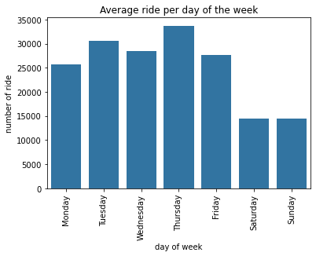

## (relation between day of week and duration of trip)

> intrestingly Saturday and Sunday has the heighst duration for trip although in lower duration they're the lowest as in holiday people go biking for entertainment or sport not for going work or school (which is usually will be near otherwise they'll use public transport :) )

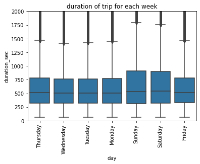

## (relation between Gender and duration of trip)

> interstingly male has the lowest duration for trip than female or others (males are lazier :) )

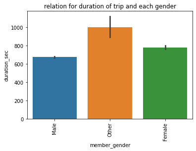

## (relation between user type and duration of trip)

> interstingly the customer has much more duration for trip than subscriber (which also indicate that subscriber usually person going to workplace rather than customer who just use it for sporting or entertainment

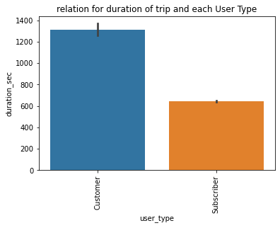

## (relation between gender, day of week and duration of trip)

> we see that male are much more in the whole week but more from Monday to Friday while Female and others have much more trip in the weekend also we can see that the relaton between trip duration is more with others then Female then Male

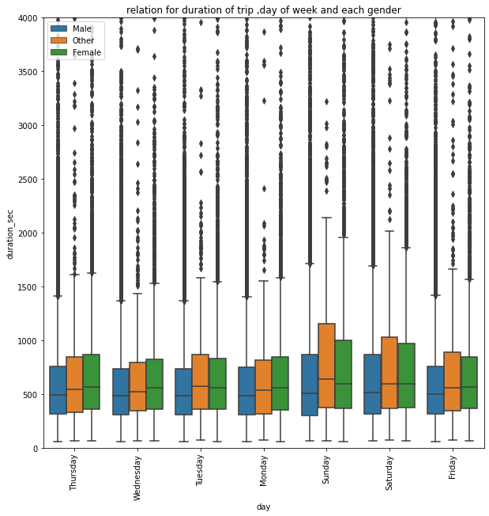

## (relation between user type, day of week and duration of trip)

> the same thing is seen with relation between subscribers customers and trip duration although subscriber have much more trip than customers but customers tend to have much trip duration especially in the weekend

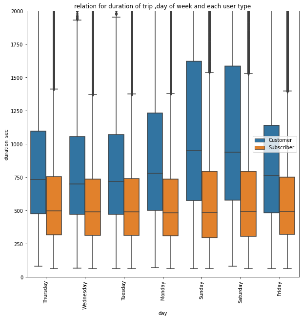

```
[NbConvertApp] Converting notebook slide_deck_template.ipynb to slides
[NbConvertApp] Writing 722629 bytes to slide_deck_template.slides.html
```